# Testing IHS

## Prepare covariates for clustering

```r
library(tidyverse)
library(terra)
library(sf)
library(leaflet)
library(scico)
library(e1071)
library(fclust)
```

Steps:

- squish
- smooth
- aggregate
- rescale
- stats

```r
terr_dir <- file.path('data_spatial', 'terrain_morphometry')

slope <- rast(file.path(terr_dir, 'Slope_1m.tif'))
planc <- rast(file.path(terr_dir, 'PlanC_1m.tif'))
profc <- rast(file.path(terr_dir, 'ProfC_1m.tif'))
twind <- rast(file.path(terr_dir, 'TWI_1m.tif'))
```

### Squish

Outlier handling is only necessary if the kurtosis statistic indicates:

```r
kurt_stats <- sapply(list(slope, planc, profc, twind),
       function(i) { e1071::kurtosis(i[], na.rm = T) })
names(kurt_stats) <- c('slope', 'planc', 'profc', 'twind')
kurt_stats[kurt_stats > 1]
```

```
#>        slope        planc        profc
#>     3.836887 43905.591182    32.513493
```

Per above, only `twind` escapes this treatment, and `planc` really needs a haircut.

```r
# curvatures have -inf-0-inf style parameters centered on 0 so both
# extremes need a trim:
planc_sq <- planc
planc_sq[] <-
  scales::oob_squish(planc_sq[],
                     range = quantile(planc_sq[],
                                      c(0.001, 0.999),
                                      na.rm = TRUE)
                     )
profc_sq <- profc
profc_sq[] <-
  scales::oob_squish(profc_sq[],
             range = quantile(profc_sq[],
                              c(0.001, 0.999),
                              na.rm = TRUE)
             )

# slope is a 0-inf parameter so only its top end needs a trim
slope_sq <- slope
slope_sq[] <-
  scales::oob_squish(slope_sq[],
                     range = quantile(slope_sq[],
                                      c(0.000, 0.999),
                                      na.rm = TRUE))
```

### Smooth

Working with 10 m cells for this exercise. Aggregating straight to 10m can produce strange artefacts in the outputs which correspond to a loss of local spatial autocorrelation. Some autocorrelation loss is unavoidable with aggregation, but the effect can be minimised by using a low-pass mean or median filter with roughly the same window size as the target cell size for aggregation, immediately prior to aggregating.

Note that median filters are generally a lot slower! While a full raster dataset may have a skewed histogram globally, this is (usually) less of a concern over a small local window size due to good ol’ autocorrelation. You can probably get away with the mean.

First, generate a focal window as a weighted matrix

```r
 # 11 x 11 cells - must be odd
circ10 <- focalMat(slope, 5, type = 'circle')
```

Then smooth

```r
slope_med10 <- focal(slope_sq, w = circ10, fun = 'mean')
planc_med10 <- focal(planc_sq, w = circ10, fun = 'mean')
profc_med10 <- focal(profc_sq, w = circ10, fun = 'mean')
twind_med10 <- focal(twind, w = circ10, fun = 'mean')
```

### Aggregate

```r
slope_10m <- terra::aggregate(slope_med10, fact = 10, cores = 3)
planc_10m <- terra::aggregate(planc_med10, fact = 10, cores = 3)
profc_10m <- terra::aggregate(profc_med10, fact = 10, cores = 3)
twind_10m <- terra::aggregate(twind_med10, fact = 10, cores = 3)
```

### Rescale

Note: Experimented unsuccessfully with z-score normalisation. Adding scaled x and y coordinates from cell centers also didn’t improve the clustering stats. Changing the plan and profile curvature scaling from -50-50 to 0-100 makes no difference to the outcomes.

```r
slope_sc <- slope_10m
planc_sc <- planc_10m
profc_sc <- profc_10m
twind_sc <- twind_10m

slope_sc[] <- scales::rescale(slope_sc[], to = c(0, 100))
# note that scaling these to 0-100 doesn't have any apparent impact on the
# clustering stats but does make the covariate density plot look nicer
planc_sc[] <- scales::rescale(planc_sc[], to = c(-50, 50))
profc_sc[] <- scales::rescale(profc_sc[], to = c(-50, 50))
twind_sc[] <- scales::rescale(twind_sc[], to = c(0, 100))

covs <- rast(list('slope' = slope_sc,
                  'planc' = planc_sc,
                  'profc' = profc_sc,
                  'twind' = twind_sc))
```

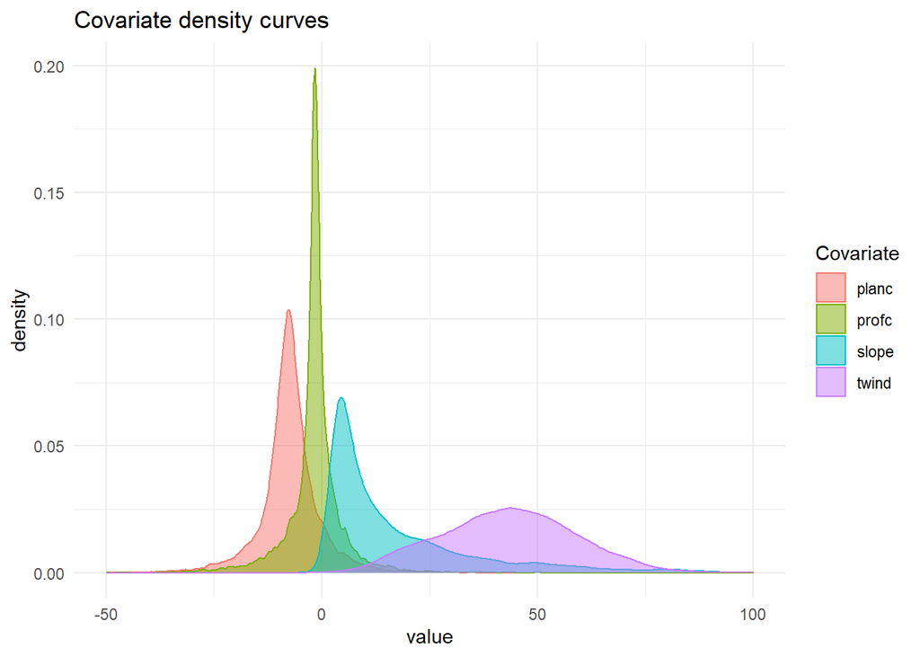

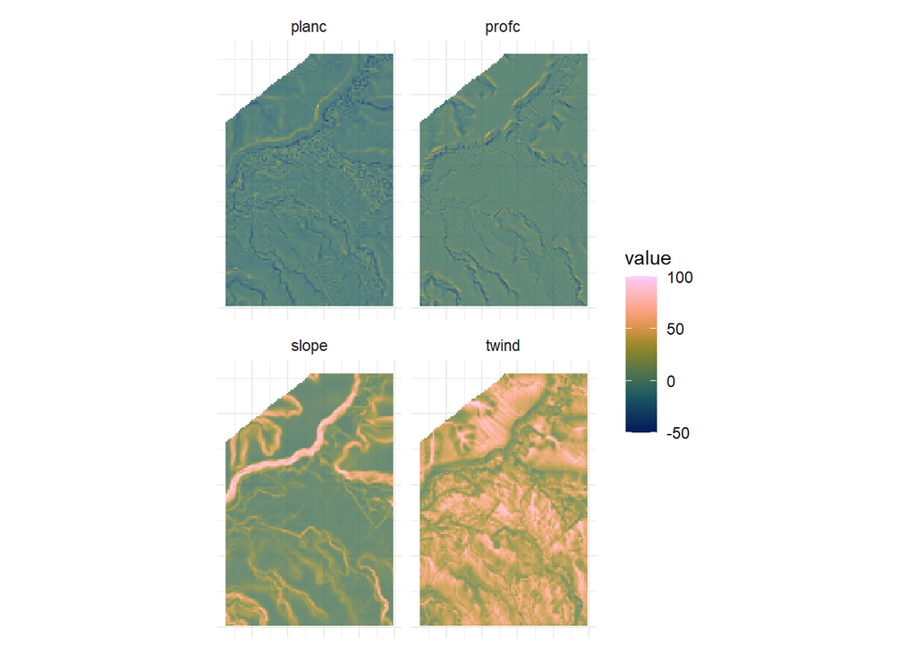

Write the processed input rasters to disk for future use and so they can be tested in the SOLIM software.

```r
if(!dir.exists(file.path('data_spatial', 'processed_covariates'))) {
  dir.create(file.path('data_spatial', 'processed_covariates'))
}
out_dir <- file.path('data_spatial', 'processed_covariates')

writeRaster(x = covs,
            filename  = file.path(out_dir, paste0(names(covs), '.tif')),
            overwrite = TRUE,
            datatype  = 'FLT4S',
            NAflag    = -9999,
            gdal      = "COMPRESS=LZW",
            names     = names(covs))
```

## Cluster the data

Time to check how clusterable this dataset is, and what range *c* should take

```r
cont_vars_df <- as.data.frame(covs) %>%
  tibble::rownames_to_column('cellno') %>%
  dplyr::mutate(cellno = as.integer(cellno)) %>%
  dplyr::filter(complete.cases(.)) %>%
  dplyr::select(cellno, everything())
```

This gives us 12434 cases to cluster.

Can’t check for optimal cluster number (or range of same) without doing the work first, so below model objects are computed for *c* 3 through 15

```r
if(!dir.exists(file.path('models'))) {
  dir.create(file.path('models'))
}

# ~2s each

set.seed(42) # do this to ensure script spits out same surfaces each time
cm_03 <- e1071::cmeans(cont_vars_df[, -1], centers = 3)
set.seed(42)
cm_04 <- e1071::cmeans(cont_vars_df[, -1], centers = 4)
set.seed(42)
cm_05 <- e1071::cmeans(cont_vars_df[, -1], centers = 5)
set.seed(42)
cm_06 <- e1071::cmeans(cont_vars_df[, -1], centers = 6)
set.seed(42)
cm_07 <- e1071::cmeans(cont_vars_df[, -1], centers = 7)
set.seed(42)
cm_08 <- e1071::cmeans(cont_vars_df[, -1], centers = 8)
set.seed(42)
cm_09 <- e1071::cmeans(cont_vars_df[, -1], centers = 9)
set.seed(42)
cm_10 <- e1071::cmeans(cont_vars_df[, -1], centers = 10)
set.seed(42)
cm_11 <- e1071::cmeans(cont_vars_df[, -1], centers = 11)
set.seed(42)
cm_12 <- e1071::cmeans(cont_vars_df[, -1], centers = 12)
set.seed(42)
cm_13 <- e1071::cmeans(cont_vars_df[, -1], centers = 13)
set.seed(42)
cm_14 <- e1071::cmeans(cont_vars_df[, -1], centers = 14)
set.seed(42)
cm_15 <- e1071::cmeans(cont_vars_df[, -1], centers = 15)

invisible(purrr::map2(list(cm_03, cm_04, cm_05, cm_06, cm_07, cm_08, cm_09,
                 cm_10, cm_11, cm_12, cm_13, cm_14, cm_15),
            seq(3,15,1),
            function(obj, i) {
              out_name <- paste0('cmeans_', sprintf('%02d', i), '.rds')
              saveRDS(obj, file.path('models', out_name))
              }
            ))
```

Now calculate and plot the F, H and S statistics for each model:

```r
fh_stats <- purrr::map2_dfr(list(cm_03, cm_04, cm_05, cm_06,
                                 cm_07, cm_08, cm_09, cm_10,
                                 cm_11, cm_12, cm_13, cm_14, cm_15),
                seq(3,15,1), function(obj, i) {
  f <- fclust::PC(obj[['membership']])
  h <- fclust::PE(obj[['membership']])
  s <- fclust::XB(Xca = cont_vars_df[, -1],
                  U = obj[['membership']],
                  H = obj[['centers']], m = 2)
  # scaling functions from Burrough et al 2000, p. 40.
  # note S doesn't need this treatment
  scale_f <- (f - 1/i) / (1 - 1/i)
  scale_h <- (h - (1 - f)) / (log(i) - (1 - f))
  data.frame("N" = i,
             "F" = scale_f,
             "H" = scale_h,
             "S" = s,
             "fh_ratio" = round(f/h, 3))
})
```

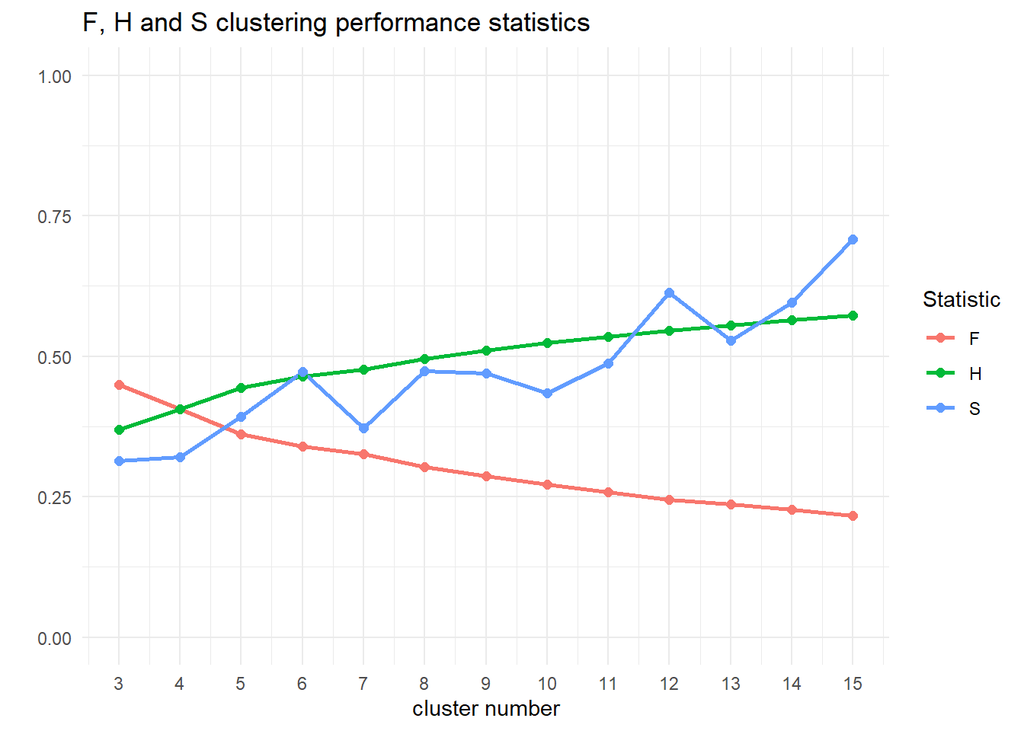